# Many ways to be motivated

Week 11 · Chapter 10 · Theoretical views of motivation

Study · Week 11

Read Chapter 10 of the textbook (Eggen & Kauchak, 2025) before you read this brief. Last week you asked what happens after a behavior. This week you ask why a person starts, keeps going, or stops. Four groups of theories answer the question in four ways, and each one sees something the others miss.

About 40 minutes plus the lecture: reading, two places you stop and write, and fifteen quick checks.

Then watch **the lecture on the four questions** in Canvas. It turns this week’s theories into four questions a student asks about every task.

## Start with your own goal

Take two minutes to write down one goal of yours, personal or professional. Then answer four questions about it:

- **Why** do you want it?
- **What could stop you?**
- **How confident are you** that you will reach it, from 1 to 5?
- **What is the plan?**

Keep your answers. Each question belongs to a theory below, and all four return in the lecture.

## A belief novice teachers may have

**Some students are motivated and some are not.** According to this belief, motivation is one amount that a student has more or less of, and a teacher’s job is to find the unmotivated students and add some.

In this week’s case, three students used the same AI tool on the same assignment. Emma wrote her best work of the year, Michael pasted an answer and walked away, and Luis got a B in two hours, the way he always does. All three were motivated, but they were motivated **toward different things, for different reasons**.

There are many ways to be motivated, and a teacher who sees only one of them will misread most of the room.

## What motivation is

Chapter 10 defines **motivation** as the process that starts goal-directed activity and keeps it going. Both *starts* and *keeps going* matter, because a student who begins well and quits in week three has a motivation problem as real as one who never begins.

Intrinsic motivation Doing something for its own sake. You read the novel because you want to know what happens, so the activity is the reward.

Extrinsic motivation Doing something as a means to an end, such as a grade, praise, money or avoiding trouble. You read the novel because there is a quiz on Friday.

Motivation to learn A student’s tendency to find school activities meaningful and worthwhile, and to try to get the learning out of them (Brophy, 2010). It is the target in a classroom, and a student can be extrinsically motivated and still want to learn.

The same act can carry either motivation. Reading a book because you enjoy the story is intrinsic, whereas reading the same book to prepare for a test is extrinsic. Most of what students do in school mixes the two.

True or false?

Extrinsic motivation is the bad kind. A teacher should try to get rid of it.

Not quite Grades, deadlines and praise get a lot of good work done. The problem comes when a reward replaces an interest the student already had, which is the topic of a later section.

Right Most school work mixes both. Extrinsic motivation becomes a problem in specific conditions, and a later section names them.

## Four views of one student

Chapter 10 groups the theories into four views, and each view asks a different question about the same student.

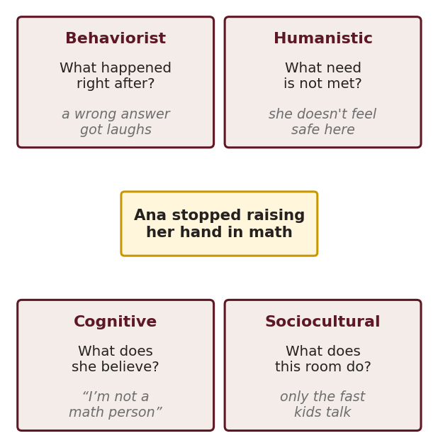

Four views of one student. Each asks a different question, and each finds a different answer.

All four interpretations of Ana could be true at once, and they suggest four different first moves for her teacher. The brief now examines them one at a time.

## The behaviorist view

This view applies last week’s theory to motivation. A motivated student is one whose behavior increased because reinforcers followed it, so more time studying *is* the motivation, and praise, comments on homework and good grades are the motivators.

The view explains a lot. Luis writes the essay the night before because the night-before essay has earned a B every time. The outline also removes his panic. When removing something unpleasant makes a behavior go up, the process is negative reinforcement, and it keeps the last-minute habit alive.

### When rewards backfire

Mila asked which option was *worth more*. Last week left a question about her: what happens to a task she liked, once it earns points?

In the classic study, preschoolers who already liked drawing were split into three groups (Lepper et al., 1973). One group was told they would get a “Good Player” certificate for drawing, another got the same certificate as a surprise afterward, and a third got nothing. Two weeks later, the markers went back out during free time.

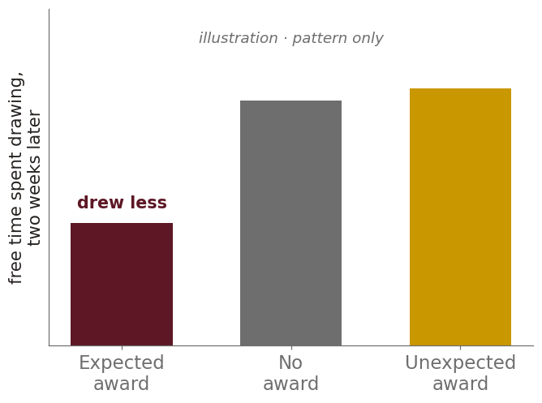

The pattern in the drawing study. Children who drew for an expected award later chose drawing less often. The surprise award did no harm.

The children who drew *for the certificate* drew less on their own, and the surprise did no harm. This is the **overjustification effect**: an expected reward for a task the learner already enjoys can turn “I draw because I like it” into “I draw for certificates.” When the certificates stop, the drawing stops with them.

Deci (1971) found the same pattern with college students and puzzles. Students paid a dollar per puzzle spent less free time on the puzzles once the pay stopped, whereas students who got only verbal encouragement kept playing. A review of 128 experiments confirmed that **expected, tangible rewards for interesting tasks** lower interest, and that praise that gives information about competence tends to raise it (Deci et al., 1999).

**Read the conditions.** The effect needs a task the learner *already* found interesting and a reward they expected. A sticker for a boring worksheet cannot damage an interest that was never there, and praise for real accomplishment is information, which helps.

True or false?

The drawing study shows that rewards always lower motivation.

Read the conditions again The surprise award did no harm. The drop came from an **expected** reward for a task the children **already liked**.

Right Only the expected award lowered drawing. A surprise, or a reward for a task nobody liked, works differently.

**What behaviorism leaves out.** Behaviorism can tell you that Emma’s effort went up. It cannot tell you why one question, *“is this assignment actually useful?”*, changed everything, because the answer happened inside her head.

## The humanistic view

Humanistic theories consider the whole person, including needs, emotions, attitudes and even physical state, along with thoughts and behaviors. Their central claim is that people are built to grow, and that they will grow when their needs are met.

### Maslow’s hierarchy

Maslow (1970) arranged human needs in a hierarchy. The lower four are **deficiency needs**: survival, safety, belonging, and esteem. When one is unmet, it draws attention toward itself. The top is a **growth need**, self-actualization, which means becoming all you are able to become. Growth needs are never satisfied completely, because meeting them makes them grow.

In a classroom, a hungry student is thinking about lunch. A student who fears being laughed at is thinking about safety, as Ana is.

**The hierarchy is not a staircase.** Maslow himself later warned against the “false impression that a need must be satisfied 100 percent before the next need emerges” (Maslow, 1987, p. 69). People in hard poverty still love, belong, and make art. Unmet needs make learning harder, but they do not make it impossible.

True or false?

According to Maslow, a student whose family is struggling to pay rent cannot be motivated by belonging or by learning until that need is fully met.

Not quite Maslow said this himself: no need has to be met 100 percent before the next one matters. The struggle makes school harder, and the student’s other needs remain active.

Right Unmet needs draw attention, but the higher needs remain active. Maslow himself corrected the staircase interpretation.

Carl Rogers added a stance for teachers, **unconditional positive regard**, which means treating a student as a person of worth regardless of what they do (Rogers & Freiberg, 1994). You can reject a behavior and still accept the student.

### Self-determination theory: C.A.R.E.

Self-determination theory proposes that every person has three basic psychological needs (Ryan & Deci, 2000). When the context meets them, intrinsic motivation and well-being follow, and when it frustrates them, both suffer.

Competence We all want to feel capable. Tasks with the right amount of challenge, and feedback that shows progress, meet this need.

Autonomy We all want to make our own decisions. Real choices, and a reason for the task, meet this need, whereas a choice between two worksheets offers very little.

Relatedness We all want to belong. This need is met when teachers know their students and when students work with each other.

In this course the three needs get a fourth letter. **C.A.R.E.** is Competence, Autonomy, Relationships, and the **Environment** that supports them, with equity built in. The fourth letter is the teacher’s part, because the needs belong to the student, and the environment either meets them or does not.

Check yourself

A teacher lets each student choose the topic of their persuasive essay, and explains how the essay format shows up in college applications. Which need is she supporting most directly?

Look at what she gave them Competence comes from challenge and feedback on progress. She gave them a **choice** and a **reason**.

Yes A real choice and a reason for the task are the two main supports for autonomy.

No one is working together yet Relatedness is about belonging and connection. Nothing here involves other people.

Higher up Deficiency needs are survival, safety, belonging and esteem. Choice is a self-determination need.

## The cognitive view

Cognitive theories claim that people act on what they **believe and expect**. The same F means one thing to a student who thinks “I didn’t study” and another to a student who thinks “I’m not smart.” Five ideas from Chapter 10 matter most.

### 1. Expectancy × value

A student’s motivation depends on two beliefs (Eccles & Wigfield, 2002). **Expectancy** asks, can I do this? **Value** asks, do I care about it? The two multiply.

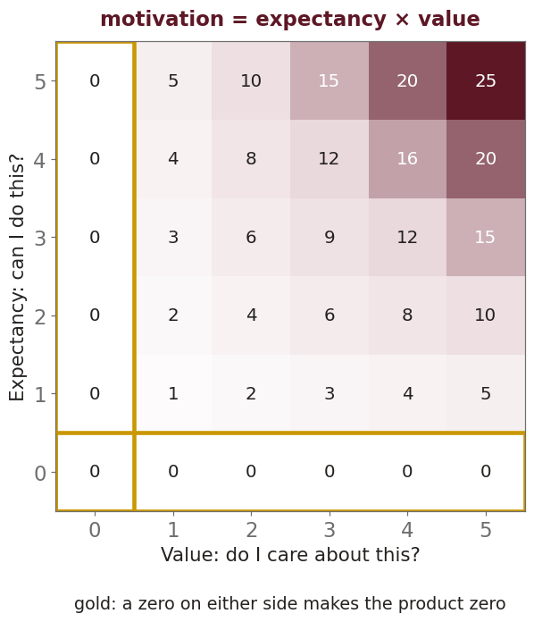

Expectancy times value. A zero on either side makes motivation zero, however high the other side is.

Because the beliefs multiply, a confident student who sees no reason to do the task scores zero, and so does a student who cares deeply and is sure they will fail. More of one cannot replace the other.

Value comes in three kinds, and it has a cost:

| **Intrinsic value** | I enjoy it. |
| --- | --- |
| **Attainment value** | It matters to who I am. A runner cares about running times. |
| **Utility value** | It is useful for something I want. |
| **Cost** | What it takes from me: effort, time I could spend on something else, anxiety. |

Teachers often forget cost. A task can be interesting, important and useful, and students may still choose an option that costs them less. Luis’s outline lowers the cost of the essay.

Check yourself

Jordan has run cross-country since sixth grade. He trains hard for the regional meet because, in his words, “I’m a runner. That’s who I am.” The value he sees in training is mostly:

Close He may enjoy it too. His words point somewhere else: being a runner is part of who he is.

Useful for what? Utility value is usefulness for another goal. He isn’t training for a scholarship or a grade.

Yes “That’s who I am” shows that doing well matters to his identity, which is attainment value.

Cost is the price Hard training is a high cost in effort. He pays it because the value is high.

True or false?

A student who finds a subject very useful, and is sure they will fail it, will probably show low motivation in it.

Right Expectancy and value **multiply**. Very high value times an expectancy near zero is still near zero.

Not quite High value cannot rescue a student who is sure they will fail. The two **multiply**, so a zero on either side wins.

### 2. Self-efficacy

You met this idea last week. **Self-efficacy** is a person’s belief that they can do a specific task (Bandura, 1997). It is narrower than self-esteem, which is how you feel about yourself in general, because it concerns *this* task: I can solve this equation, I can write this essay. A student can have high self-esteem and low self-efficacy in math.

Self-efficacy has four sources, from strongest to weakest:

Mastery experiences Succeeding at the task yourself is the strongest source. Easy wins do little, whereas real success after real effort does a lot.

Vicarious experiences Watching someone **similar** to you succeed. Last week’s two students watched Mila win, saw no one like themselves, and stopped trying.

Verbal persuasion Hearing from someone you trust that you can do it. It helps, but it does not last if the next experience says otherwise.

Physiological and emotional states Interpreting your own body. A student may interpret a racing heart before a test as “I’m not ready.”

Self-efficacy predicts what a student chooses, how hard they try, and how long they keep going when it gets difficult.

Check yourself

DeShawn is sure he can’t do the long jump. Then he watches Malik, who is his height and was in his beginner group last year, clear a good distance. DeShawn decides to try. Which source of self-efficacy is at work?

Not yet A mastery experience is DeShawn succeeding himself. He hasn’t jumped yet.

Yes He watched someone **similar** succeed. Malik’s height and history are what make it work.

Nobody said anything Verbal persuasion is someone telling him he can. Here he only watched.

Not his body A physiological state is reading his own body, like a racing heart. Nothing here is about that.

True or false?

A student with high self-esteem will have high self-efficacy in every subject.

Not quite Self-esteem is how you feel about yourself in general. Self-efficacy is about **one task**. A student can feel fine about themselves and be sure they can’t do algebra.

Right Self-efficacy is specific to a task and self-esteem is general, so the two can differ.

### 3. Attributions

After a success or a failure, people explain it to themselves. **Attribution theory** classifies those explanations on three dimensions (Weiner, 1986):

|  | **Locus** | **Stability** | **Control** |
| --- | --- | --- | --- |
| **Ability** “I’m not good at this” | inside me | stable | not controllable |
| **Effort** “I didn’t study” | inside me | changes | controllable |
| **Task difficulty** “the test was unfair” | outside me | stable | not controllable |
| **Luck** “I guessed well” | outside me | changes | not controllable |

The dimensions predict what happens next. A student who blames effort expects to do better if they study, and often does. A student who blames ability expects to fail again and sees no reason to try. Repeated stable, uncontrollable explanations can lead to **learned helplessness**, the belief that nothing you do will change the outcome, so you stop trying (Seligman, 1975).

Check yourself

Four students get their French quizzes back. Which one is in the most danger of learned helplessness?

Jade can act Effort is internal, changes, and is controllable. She can study next time, and she expects it to work.

Close, but she protects herself Tori’s explanation is stable and out of her control, so her motivation may drop. It also protects her, because she can blame the teacher and keep her belief in her own ability.

Yes Ability is internal, stable and uncontrollable. “I never will” predicts that effort won’t matter, and that prediction can lead to learned helplessness.

He did well Ben succeeded. Luck won’t make him expect success next time, and it won’t make him give up either.

### 4. Self-worth

Many students believe their worth depends on looking able. **Self-worth theory** proposes that they will protect that belief, sometimes at the cost of learning (Covington, 1992). The surest protection is not trying, because a failure without effort says nothing about ability.

For example, one student has trouble keeping up in chemistry. The midterm is worth 25 percent of the grade. He goes on a ski trip the weekend before, gets a D, and tells everyone it was the trip. This is **self-handicapping**: he made a failure likely and gave it a cause other than his ability.

Check yourself

The night before a big history test, Kayla plays video games until 2 a.m. The next day she tells everyone, “I didn’t even study.” She has been struggling in the class. Self-worth theory says she is most likely:

Not about improving A mastery goal is about getting better. Staying up all night makes getting better less likely.

Close Learned helplessness is giving up because effort won’t matter. Kayla is doing something more active, because she builds an excuse **in advance**.

Maybe, and it doesn’t explain the excuse Interest wouldn’t explain why she tells everyone she didn’t study.

Yes A bad grade now says “no sleep,” not “not able.” She made failure likely and gave it a cause other than her ability.

### 5. Goals and mindset

A **mastery goal** is about getting better, such as understanding the content or improving a skill. A **performance goal** is about how you look next to others, and it comes in two kinds (Elliot & McGregor, 2001). **Approach** means wanting to beat the others, and **Avoidance** means not wanting to look worse than the others. Avoidance goals are the most damaging. Mastery goals go with interest and persistence, although performance-approach goals can still go with good grades.

Check yourself

Dana understands little of the chemistry unit. She never asks a question in class, because she doesn’t want the others to think she is slow. Her goal is best described as:

She isn’t trying to get better A mastery goal would make her ask. Understanding the unit isn’t what she’s protecting.

Not beating anyone Performance-approach is wanting to outdo others. Dana wants to avoid looking worse.

Yes Her goal is to not look slow. Her case shows why avoidance goals are the most damaging: she gives up the help she needs.

Intrinsic is about the activity Nothing here says she does chemistry for its own sake.

A **growth mindset** is the belief that ability can grow with effort and good strategy, and a **fixed mindset** is the belief that it can’t (Dweck, 2006). You took the Theories of Intelligence scale in Week 3. Large reviews find that short mindset programs have small effects on grades overall (Sisk et al., 2018), whereas a national study found a small, real benefit for lower-achieving students in schools where the peers supported the message (Yeager et al., 2019). Mindset matters, but a poster about it does little.

True or false?

Research shows that a short growth-mindset lesson raises grades a lot, for all students.

Not quite Large reviews find **small** average effects. The real benefit showed up mostly for lower-achieving students, in schools where peers supported the message.

Right The effects are small on average and depend on the student and the school.

Commit first

In the case, Michael pasted an AI answer and said, *“I wasn’t going to do it well anyway. This way it’s done.”*

**Use two ideas from the cognitive view to explain his sentence.** Show how each idea leads to his choice. Two or three sentences.

**“I wasn’t going to do it well anyway” is an expectancy, and it is low.** It is a belief about himself on this task, so it shows low **self-efficacy**. It also sounds like an **ability** attribution, which is internal, stable and out of his control. With expectancy near zero, the product is near zero, however much he values the grade.

**“This way it’s done” protects his self-worth.** A pasted essay that does badly says nothing about Michael, but a real essay that does badly would, so not trying is safer.

**The belief in this sentence drives his decision.** If the belief changes, the choice can change. On Thursday we study where it came from.

### Interest and emotion

**Situational interest** is sparked by the moment, such as a surprising demo, a puzzle or a story. **Personal interest** is the student’s own and lasts. Situational interest can grow into personal interest when the student keeps coming back to it (Hidi & Renninger, 2006).

**Anxiety** has two parts, worry (the thoughts) and emotionality (the racing heart). A little arousal helps, but a lot of it crowds working memory, which you studied in Week 6, and a student who knows the material may blank on the test.

True or false?

A student can know the material well and still blank on a test, because worry is taking up working memory.

Right Worry uses the same limited space the student needs to think. That is why anxious students often know more than their scores show.

Not quite Anxiety crowds working memory, which you met in Week 6. A student can know the material and still blank.

## The sociocultural view

Sociocultural theory, which you studied with Vygotsky in Week 3, proposes that motivation is social. People are motivated to take part in the communities they belong to, and to become the kind of person those communities value. A student who sees the class as “people like me who do this” works for the class.

Community of learners A classroom where the teacher and students work together to help everyone learn. Everyone is expected to contribute, and mistakes are part of the work. Ana’s room, where only the fast students talk, is the opposite.

Motivational zone of proximal development The match between a task and what the learner already knows and cares about. The task is close enough to their experience to stir interest and far enough to be worth doing. A task that is too familiar is boring, and one that is too distant means nothing (Brophy, 1999).

Identity and participation A student learns what “people like us” do from the people around them, such as family, friends and the class. Emma chose a problem from her own family’s life, the bus her mother takes to work, so the task became part of her community.

Check yourself

Ms. Reyes runs her science class as a lab group. Every student has a role, mistakes are discussed openly as data, and the class’s work goes on display for the whole school. Students who used to sit silent now argue about results. Which view best explains the change?

Part of it, at most The display might reinforce something. It doesn’t explain why silent students started arguing about results. Look at the roles and the shared work.

Close Safety matters here, and open mistakes help it. The change described is about joining a group with a shared job, which is the sociocultural interpretation.

Nothing tells us what they believe The case describes the room. It says nothing about why the students think they succeed or fail.

Yes With roles, shared work, mistakes as data and an audience, the class became a group where everyone takes part. Students work for the community they belong to.

## Return to the case: one tool, three motivations

Commit first

Luis has written every major assignment the night before, from an AI outline, all year. He gets Bs. It always works.

**Pick two of the four views. What does each one say Luis is motivated by?** Say what one view sees that the other misses. Two or three sentences.

Any two views will work. All four appear below.

**Behaviorist:** the B reinforces the night-before habit every time, and the outline removes his panic, which is negative reinforcement. **Cognitive:** his expectancy is high and well earned, and his goal is a solid grade at the lowest **cost**, which is a performance goal with a sensible price. **Humanistic:** he feels competent, and the plan protects him from a stress he knows well. **Sociocultural:** we know little about his community, so we would ask who in his life works this way.

Each view sees a motivated student. Case question 3 asks whether that is a *problem*, so bring your answer.

## Motivation and AI tools

The tool in the case behaved the same way three times, because it answered the question it was asked. Emma asked it to **justify** the task, Michael asked it to **replace** him, and Luis asked it to **organize** him. Each request tells you what the student was motivated by, and the tool read none of them.

This has two consequences for a tool you build:

- **A tool that does the task removes the mastery experience.** The strongest source of self-efficacy is succeeding yourself. Michael got an essay and no evidence that he could write one.
- **Your tool’s feedback is a motivator.** Praise that gives information about competence supports motivation, whereas feedback that tells the student what to fix, with no choice and no reason, works against autonomy. In your Friction Move this week (**Rubric**), you classify two AI feedback styles on those lines.

## Check yourself

Check yourself

A middle school gives students a pizza party for every 10 books they read. Reading goes up during the program. After the program ends, the students who loved reading before it started read less than they used to. The best explanation is:

Yes The program gave an expected, tangible reward for a task they already enjoyed. Reading became “for pizza,” and when the pizza stopped, so did some of the reading.

They can still read Learned helplessness is the belief that effort won’t change the outcome. Nothing here says they expect to fail.

They are good readers These were the students who already loved reading. Their confidence isn’t the issue.

Wrong direction An extinction burst is a rise right after the reinforcer stops. Here reading dropped below where it started.

By now you should **Have an answer to case question 1**, which asks what changed for Emma once she knew the assignment was useful. The obvious word is not quite the right one.

**Your goal from the start of this brief.** Which of your four answers was expectancy, which was value, which was cost? *In person:* bring it Tuesday. *Online:* think it through this week.

**The four-questions lecture,** watched before Tuesday.

*This week feeds Milestone 3: what your tool’s feedback does to a learner’s motivation.*

## Sources

Bandura, A. (1997). *Self-efficacy: The exercise of control.* W. H. Freeman.

Brophy, J. (1999). Toward a model of the value aspects of motivation in education: Developing appreciation for particular learning domains and activities. *Educational Psychologist, 34*(2), 75–85.

Brophy, J. (2010). *Motivating students to learn* (3rd ed.). Routledge.

Covington, M. V. (1992). *Making the grade: A self-worth perspective on motivation and school reform.* Cambridge University Press.

Deci, E. L. (1971). Effects of externally mediated rewards on intrinsic motivation. *Journal of Personality and Social Psychology, 18*(1), 105–115.

Deci, E. L., Koestner, R., & Ryan, R. M. (1999). A meta-analytic review of experiments examining the effects of extrinsic rewards on intrinsic motivation. *Psychological Bulletin, 125*(6), 627–668.

Dweck, C. S. (2006). *Mindset: The new psychology of success.* Random House.

Eccles, J. S., & Wigfield, A. (2002). Motivational beliefs, values, and goals. *Annual Review of Psychology, 53*, 109–132.

Eggen, P. D., & Kauchak, D. P. (2025). *Using educational psychology in teaching* (12th ed.). Pearson. **This week: Chapter 10.**

Elliot, A. J., & McGregor, H. A. (2001). A 2 × 2 achievement goal framework. *Journal of Personality and Social Psychology, 80*(3), 501–519.

Hidi, S., & Renninger, K. A. (2006). The four-phase model of interest development. *Educational Psychologist, 41*(2), 111–127.

Lepper, M. R., Greene, D., & Nisbett, R. E. (1973). Undermining children’s intrinsic interest with extrinsic reward: A test of the “overjustification” hypothesis. *Journal of Personality and Social Psychology, 28*(1), 129–137.

Maslow, A. H. (1970). *Motivation and personality* (2nd ed.). Harper & Row.

Maslow, A. H. (1987). *Motivation and personality* (3rd ed.). Harper & Row.

Rogers, C. R., & Freiberg, H. J. (1994). *Freedom to learn* (3rd ed.). Merrill.

Ryan, R. M., & Deci, E. L. (2000). Self-determination theory and the facilitation of intrinsic motivation, social development, and well-being. *American Psychologist, 55*(1), 68–78.

Seligman, M. E. P. (1975). *Helplessness: On depression, development, and death.* W. H. Freeman.

Sisk, V. F., Burgoyne, A. P., Sun, J., Butler, J. L., & Macnamara, B. N. (2018). To what extent and under which circumstances are growth mind-sets important to academic achievement? Two meta-analyses. *Psychological Science, 29*(4), 549–571.

Weiner, B. (1986). *An attributional theory of motivation and emotion.* Springer-Verlag.

Yeager, D. S., Hanselman, P., Walton, G. M., Murray, J. S., Crosnoe, R., Muller, C., … Dweck, C. S. (2019). A national experiment reveals where a growth mindset improves achievement. *Nature, 573*, 364–369.